# Web Scraping in R

(Slides by [Carson Sievert](https://cpsievert.github.io))

Haley Jeppson, Joe Papio, Sam Tyner

June 15, 2017

# A web of data

- In 2008, [an estimated](http://yz.mit.edu/papers/webtables-vldb08.pdf) **154 million HTML tables** (out of the 14.1 billion) contain ‘high quality relational data’!!!
- Hard to quantify how much more exists outside of HTML Tables, but there is [an estimate](https://cs.uwaterloo.ca/~x4chu/SIGMOD2015_1.pdf) of **at least 30 million lists** with ‘high quality relational data’.
- A growing number of websites/companies [provide programmatic access](http://www.programmableweb.com/category/all/apis?order=field_popularity) to their data/services via web APIs (that data typically comes in XML/JSON format).

# Before scraping, do some googling!

- If the resource is well-known, someone else has probably built a tool which solves the problem for you.
- [ropensci](https://ropensci.org/) has a [ton of R packages](https://ropensci.org/packages/) providing easy-to-use interfaces to open data.
- The [Web Technologies and Services CRAN Task View](http://cran.r-project.org/web/views/WebTechnologies.html) is a great overview of various tools for working with data that lives on the web in R.

# A web of *messy* data!

- In statistical modeling, we typically assume data is [tidy](http://vita.had.co.nz/papers/tidy-data.pdf).
- That is, data appears in a tabular form where
  - 1 row == 1 observation
  - 1 column == 1 variable (observational attribute)
- Parsing HTML/XML/JSON is easy; but putting it into a tidy form is typically *not easy*.
- Knowing a bit about modern tools & web technologies makes it *much* easier.

# Motivating Example

[interactive chart not shown]

# Inspecting elements

[figure not shown]

# Hover to find desired elements

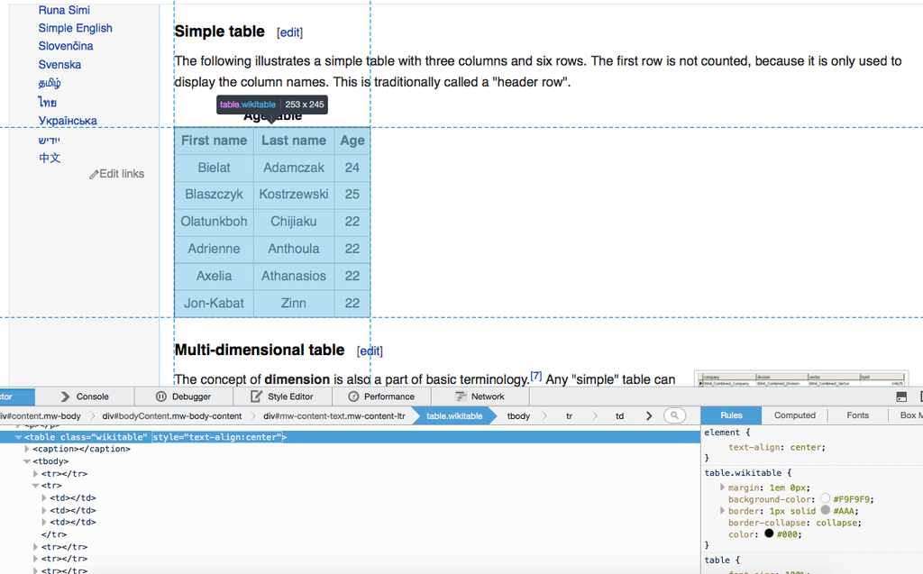

# Wikitable

```r
library(rvest)
src <- read_html("http://en.wikipedia.org/wiki/Table_(information)")
node <- html_node(src, css = ".wikitable")
```

- `".wikitable"` is a CSS selector which says: “grab nodes (aka elements) with a class of wikitable”.
- `html_table()` converts a single `<table>` node to a data frame.

```r
html_table(node, fill = TRUE)
```

```
##    First name   Last name Age NA
## 1        Tinu    Elejogun  14 NA
## 2   Blaszczyk Kostrzewski  25 NA
## 3        Lily   McGarrett  16 NA
## 4  Olatunkboh    Chijiaku  22 NA
## 5    Adrienne    Anthoula  22 NA
## 6      Axelia  Athanasios  22 NA
## 7   Jon-Kabat        Zinn  22 NA
## 8     Thabang       Mosoa  15 NA
## 9    Kgaogelo       Mosoa  11 NA
## 10                   <NA>  NA NA
## 11          ×           1   2  3
## 12          1           1   2  3
## 13          2           2   4  6
## 14          3           3   6  9
```

# Pipeable!

```r
read_html("http://en.wikipedia.org/wiki/Table_(information)") %>%
  html_node(".wikitable") %>% html_table(fill=TRUE)
```

```
##    First name   Last name Age NA
## 1        Tinu    Elejogun  14 NA
## 2   Blaszczyk Kostrzewski  25 NA
## 3        Lily   McGarrett  16 NA
## 4  Olatunkboh    Chijiaku  22 NA
## 5    Adrienne    Anthoula  22 NA
## 6      Axelia  Athanasios  22 NA
## 7   Jon-Kabat        Zinn  22 NA
## 8     Thabang       Mosoa  15 NA
## 9    Kgaogelo       Mosoa  11 NA
## 10                   <NA>  NA NA
## 11          ×           1   2  3
## 12          1           1   2  3
## 13          2           2   4  6
## 14          3           3   6  9
```

- Much easier to read/understand!

# Your Turn

Navigate [this page](http://www.wunderground.com/history/airport/KVAY/2015/2/17/DailyHistory.html?req_city=Cherry+Hill&req_state=NJ&req_statename=New+Jersey&reqdb.zip=08002&reqdb.magic=1&reqdb.wmo=99999&MR=1) and try the following:

1. Grab the table at the bottom of the page (hint: instead of grabbing a node by class with `html_node(".class")`, you can grab by id with `html_node("#id")`)
2. From the table at the top, grab the actual mean, max, and min temperature.
3. (Optional) Grab the weather history graph and write the figure to disk (`download.file()` may be helpful here).

[See here](https://gist.github.com/cpsievert/57be009120bb5298affa) for a solution (thanks Hadley Wickham for the example)

# What about non-`<table>` data?

# (selectorgadget + rvest) to the rescue!

- [Selectorgadget](http://selectorgadget.com/) is a [Chrome browser extension](https://chrome.google.com/webstore/detail/selectorgadget/mhjhnkcfbdhnjickkkdbjoemdmbfginb?hl=en) for quickly extracting desired parts of an HTML page.
- With some user feedback, the gadget find out the [CSS selector](http://www.w3.org/TR/2011/REC-css3-selectors-20110929/) that returns the highlighted page elements.
- Let’s try it out on [this page](http://www.sec.gov/litigation/suspensions.shtml)

# Extracting links to download reports

```r
domain <- "http://www.sec.gov"
susp <- paste0(domain, "/litigation/suspensions.shtml")
hrefs <- read_html(susp) %>% html_nodes("p+ table a") %>% html_attr(name = "href")
tail(hrefs)
```

```
## [1] "/litigation/suspensions/2017/34-80144.pdf"
## [2] "/litigation/suspensions/2017/34-80144-o.pdf"
## [3] "/litigation/suspensions/2017/34-80049.pdf"
## [4] "/litigation/suspensions/2017/34-80049-o.pdf"
## [5] "/litigation/suspensions/2017/34-79852.pdf"
## [6] "/litigation/suspensions/2017/34-79852-o.pdf"
```

```r
hrefs <- hrefs[!is.na(hrefs)]
pdfs <- paste0(domain, hrefs)[1:10]

for (i in 1:length(pdfs)) {
    download.file(url = pdfs[i], destfile = basename(pdfs[i]))
}
```

# Your Turn

Nativigate to Wikipedia’s [list of data structures](http://en.wikipedia.org/wiki/List_of_data_structures) use SelectorGadget + rvest to do the following:

1. Obtain a list of Primitive types
2. Obtain a list of the different Array types

[See here](https://gist.github.com/cpsievert/c1b851ff5e1bd846de46) for a solution.

# Don’t abuse your power

- If you scrape a website, please read the terms and conditions!!
- It’s sometimes more efficient/appropriate to [find the API](http://www.gregreda.com/2015/02/15/web-scraping-finding-the-api/).
- If a website public offers an API, USE IT (instead of scraping)!!!

http://www.wired.com/2014/01/how-to-hack-okcupid

http://www.vox.com/2016/5/12/11666116/70000-okcupid-users-data-release

# Web APIs

- [Server-side Web APIs](https://en.wikipedia.org/wiki/Web_API#Server-side) (Application Programming Interfaces) are a popular way to provide easy access to data and other services.
- If you (the client) want data from a server, you typically need one HTTP verb – `GET`.

```r
library(httr)
sam <- GET("https://api.github.com/users/sctyner")
content(sam)[c("name", "company")]
```

```
## $name
## [1] "Sam Tyner"
##
## $company
## [1] "Iowa State University"
```

- Other HTTP verbs – `POST`, `PUT`, `DELETE`, etc…

# Request/response model

- When you (the client) *requests* a resource from the server. The server *responds* with a bunch of additional information.

```r
sam$header[1:3]
```

```
## $server
## [1] "GitHub.com"
##
## $date
## [1] "Fri, 09 Jun 2017 21:36:07 GMT"
##
## $`content-type`
## [1] "application/json; charset=utf-8"
```

- Nowadays content-type is usually XML or JSON (HTML is great for *sharing content* between *people*, but it isn’t great for *exchanging data* between *machines*.)

# What is XML?

XML is a markup language that looks very similar to HTML.

```xml
<mariokart>
  <driver name="Bowser" occupation="Koopa">
    <vehicle speed="55" weight="25"> Wario Bike </vehicle>
    <vehicle speed="40" weight="67"> Piranha Prowler </vehicle>
  </driver>
  <driver name="Peach" occupation="Princess">
    <vehicle speed="54" weight="29"> Royal Racer </vehicle>
    <vehicle speed="50" weight="34"> Wild Wing </vehicle>
  </driver>
</mariokart>
```

- This example shows that XML can (and is) used to store inherently tabular data ([thanks Jeroen Ooms](http://arxiv.org/pdf/1403.2805v1.pdf))
- What is are the observational units here? How many observations in total?
- 2 units and 6 total observations (4 vehicles and 2 drivers).

# XML2R

XML2R is a framework to simplify acquistion of tabular/relational XML.

```
##
##          mariokart//driver mariokart//driver//vehicle
##                          2                          4
```

- The main idea of **XML2R** is to coerce XML into a *flat* list of observations.
- The list names track the “observational unit”.
- The list values track the “observational attributes”.

```r
obs # named list of observations
```

```
## $`mariokart//driver//vehicle`
##      speed weight XML_value
## [1,] "55"  "25"   " Wario Bike "
##
## $`mariokart//driver//vehicle`
##      speed weight XML_value
## [1,] "40"  "67"   " Piranha Prowler "
##
## $`mariokart//driver`
##      name     occupation
## [1,] "Bowser" "Koopa"
##
## $`mariokart//driver//vehicle`
##      speed weight XML_value
## [1,] "54"  "29"   " Royal Racer "
##
## $`mariokart//driver//vehicle`
##      speed weight XML_value
## [1,] "50"  "34"   " Wild Wing "
##
## $`mariokart//driver`
##      name    occupation
## [1,] "Peach" "Princess"
```

```r
collapse_obs(obs) # group into table(s) by observational name/unit
```

```
## $`mariokart//driver`
##      name     occupation
## [1,] "Bowser" "Koopa"
## [2,] "Peach"  "Princess"
##
## $`mariokart//driver//vehicle`
##      speed weight XML_value
## [1,] "55"  "25"   " Wario Bike "
## [2,] "40"  "67"   " Piranha Prowler "
## [3,] "54"  "29"   " Royal Racer "
## [4,] "50"  "34"   " Wild Wing "
```

- What information have I lost?
- I can’t map vehicles to the drivers!

```r
library(dplyr)
obs <- add_key(obs, parent = "mariokart//driver", recycle = "name")
```

```
## A key for the following children will be generated for the mariokart//driver node:
## mariokart//driver//vehicle
```

```r
collapse_obs(obs)
```

```
## $`mariokart//driver`
##      name     occupation
## [1,] "Bowser" "Koopa"
## [2,] "Peach"  "Princess"
##
## $`mariokart//driver//vehicle`
##      speed weight XML_value           name
## [1,] "55"  "25"   " Wario Bike "      "Bowser"
## [2,] "40"  "67"   " Piranha Prowler " "Bowser"
## [3,] "54"  "29"   " Royal Racer "     "Peach"
## [4,] "50"  "34"   " Wild Wing "       "Peach"
```

Now (if I want) I can merge the tables into a single table…

```r
tabs <- collapse_obs(obs)
left_join(as.data.frame(tabs[[1]]), as.data.frame(tabs[[2]]))
```

```
##     name occupation speed weight         XML_value
## 1 Bowser      Koopa    55     25       Wario Bike
## 2 Bowser      Koopa    40     67  Piranha Prowler
## 3  Peach   Princess    54     29      Royal Racer
## 4  Peach   Princess    50     34        Wild Wing
```

# What about JSON?

- JSON is quickly becoming *the* format for data on the web.
- JavaScript Object Notation (JSON) is comprised of two components:
  - arrays => [value1, value2]
  - objects => {“key1”: value1, “key2”: [value2, value3]}
- [jsonlite](http://cran.r-project.org/web/packages/jsonlite/index.html) is the preferred R package for parsing JSON (it’s even used by Shiny!)

# Back to Mariokart

```json
[
    {
        "driver": "Bowser",
        "occupation": "Koopa",
        "vehicles": [
            {
                "model": "Wario Bike",
                "speed": 55,
                "weight": 25
            },
            {
                "model": "Piranha Prowler",
                "speed": 40,
                "weight": 67
            }
        ]
    },
    {
        "driver": "Peach",
        "occupation": "Princess",
        "vehicles": [
            {
                "model": "Royal Racer",
                "speed": 54,
                "weight": 29
            },
            {
                "model": "Wild Wing",
                "speed": 50,
                "weight": 34
            }
        ]
    }
]
```

```r
library(jsonlite)
mario <- fromJSON("http://bit.ly/mario-json")
str(mario) # nested data.frames?!?
```

```
## 'data.frame':    2 obs. of  3 variables:
##  $ driver    : chr  "Bowser" "Peach"
##  $ occupation: chr  "Koopa" "Princess"
##  $ vehicles  :List of 2
##   ..$ :'data.frame': 2 obs. of  3 variables:
##   .. ..$ model : chr  "Wario Bike" "Piranha Prowler"
##   .. ..$ speed : int  55 40
##   .. ..$ weight: int  25 67
##   ..$ :'data.frame': 2 obs. of  3 variables:
##   .. ..$ model : chr  "Royal Racer" "Wild Wing"
##   .. ..$ speed : int  54 50
##   .. ..$ weight: int  29 34
```

```r
mario$driver
```

```
## [1] "Bowser" "Peach"
```

```r
mario$vehicles
```

```
## [[1]]
##             model speed weight
## 1      Wario Bike    55     25
## 2 Piranha Prowler    40     67
##
## [[2]]
##         model speed weight
## 1 Royal Racer    54     29
## 2   Wild Wing    50     34
```

How do we get two tables (with a common id) like the XML example?

```r
vehicles <- rbind(mario$vehicles[[1]], mario$vehicles[[2]])
vehicles <- cbind(driver = mario$driver, vehicles)
```

# Your Turn

1. Get the json data for our R workshop GitHub commit history:

```r
workshop_commits_raw <- fromJSON("https://api.github.com/repos/heike/rwrks/commits")
```

2. Find the table of commits contained in this list
3. Plot the total number of commits (number of rows) by user as a bar chart